# Gaze Following Variable Validation

Gaze following Analysis Team

Wed Jun 12 13:27:50 2019

# 1 Intro

This is the second Gaze Following preprocessing script. The goal of this file is to ensure that all variables have the values assumed by further analysis. Credit to the much code borrowed from mb1/mb1b scripts.

This script is organized around variable types being processed.

**identifiers** [should not be modified after reading and merging in 01_read_and_merge.RMD]

- lab
- subid

**trial variables**

- study_order
- trial_num
- stimulus

**moderators/exclusion variables**

- lang_group
- age_days
- gender
- trial error
- participant error
- preterm
- pilot

**DVs**

- first_shift
- latency
- n_shift_congruent
- n_shift_incongruent
- n_shift_total
- fixation_congruent
- fixation_incongruent

NOTE: No exclusions are performed in this script. These are all performed in `03_exclusion.Rmd`.

```r
d <- read_csv("processed_data/01_merged_output.csv", guess_max = 3000)
```

Data import functions are factored into a helper functions file.

```r
source("helper/preprocessing_helper.R")
```

# 2 Participant IDs

Make sure that each participant has a unique ID

```r
d %>%
  group_by(subid) %>% summarise(n = length(trial_num)) %>% filter(n > 6)
```

```
## # A tibble: 4 x 2
##   subid      n
##   <chr>  <int>
## 1 8731      12
## 2 8738      12
## 3 8767      12
## 4 ybg038    12
```

4 participants were asigned the same ID. This can be fixed by appending lab to the subid:

```r
d <- d %>% mutate(subid = paste0(lab, subid))
```

There is still one participant who has been double-coded:

```r
d %>%
  group_by(subid) %>% summarise(n = length(trial_num)) %>% filter(n > 6)
```

```
## # A tibble: 1 x 2
##   subid                             n
##   <chr>                         <int>
## 1 nusinfantlanguagecentreybg038    12
```

We will remove the eye-tracking data, as this lab hand-coded infants whose eye-tracking data was unreliable

```r
d <- d %>% filter(subid != "nusinfantlanguagecentreybg038")
```

# 3 Trial variables

The goal of this subsection is to ensure that we have the following variables.

- study_order - which counterbalance? [1:4]
- trial_num -

## 3.1 trial_order

What trial orders do we have?

```r
unique(d$study_order)
```

```
## [1] 4 3 1 2
```

We have the expected 4 study orders

# 4 trial_number

What trial numbers do we have

```r
unique(d$trial_num)
```

```
## [1] 1 2 3 4 5 6
```

We have the expected 6 trial numbers in the dataset

Next, if there aren’t exactly 6 trials for a participant, we want to make it so there are! (IE by defining a row for an ‘error’ at trial 1, 2, etc. of each baby.) First, check how many rows exist for each participant (which may not be the same as the number of trials!)

These are cases where the number of trial numbers doesn’t match the number of rows.

```r
trial_row_checker <- d %>%
  group_by(lab, subid) %>%
  summarize(trialcount = n_distinct(trial_num),
            rowcount = length(trial_num))

trial_row_checker %>%
  filter(trialcount != rowcount)
```

```
## # A tibble: 0 x 4
## # Groups:   lab [0]
## # … with 4 variables: lab <chr>, subid <chr>, trialcount <int>,
## #   rowcount <int>
```

```r
unfinished_trials <- trial_row_checker %>%
  filter(trialcount != 6)
```

# 5 stimulus

We want to make sure that the trial number and trial order correspond to the expected stimulus

```r
unique(d$stimulus)
```

```
##  [1] "ord4_t1_r"  "ord4_t2_l"  "ord4_t3_l"  "ord4_t4_r"  "ord4_t5_l"
##  [6] "ord4_t6_r"  "ord3_t1_l"  "ord3_t2_r"  "ord3_t3_r"  "ord3_t4_l"
## [11] "ord3_t5_r"  "ord3_t6_l"  "ord1_t1_r"  "ord1_t2_l"  "ord1_t3_l"
## [16] "ord1_t4_r"  "ord1_t5_l"  "ord1_t6_r"  "ord2_t1_l"  "ord2_t2_r"
## [21] "ord2_t3_r"  "ord2_t4_l"  "ord2_t5_r"  "ord2_t6_l"  "ord1_t1_rx"
## [26] "ord1_t2_lx" "ord1_t3_lx" "ord1_t4_rx" "ord1_t5_lx" "ord1_t6_rx"
## [31] "ord2_t1_lx" "ord2_t2_rx" "ord2_t3_rx" "ord2_t4_lx" "ord2_t5_rx"
## [36] "ord2_t6_lx" "ord3_t1_lx" "ord3_t2_rx" "ord3_t3_rx" "ord3_t4_lx"
## [41] "ord3_t5_rx" "ord3_t6_lx" "ord4_t1_rx" "ord4_t2_lx" "ord4_t3_lx"
## [46] "ord4_t4_rx" "ord4_t5_lx" "ord4_t6_rx" "ecr1"       "ecl2"
## [51] "ecl3"       "ecr4"       "ecl5"       "ecr6"       "ecl1"
## [56] "ecr2"       "ecr3"       "ecl4"       "ecr5"       "ecl6"
## [61] "ecr1f"      "ecl2f"      "ecl3f"      "ecr4f"      "ecl5f"
## [66] "ecr6f"      "ecl1f"      "ecr2f"      "ecr3f"      "ecl4f"
## [71] "ecr5f"      "ecl6f"
```

```r
stimuli <- read_csv("metadata/study_orders.csv") %>%
#  rename(stimulus = stimulus_check) %>%
  mutate(stimulus_check = tolower(stimulus_check))

d <- left_join(d, stimuli)


unmatched_stimuli <- as.data.frame(setdiff(d$stimulus, d$stimulus_check))

#Everything in order.  Will replace stimulus with stimulus_check

d <- d %>%
  select(-stimulus) %>%
  rename(stimulus = stimulus_check)

unique(d$stimulus)
```

```
##  [1] "ord4_t1_r" "ord4_t2_l" "ord4_t3_l" "ord4_t4_r" "ord4_t5_l"
##  [6] "ord4_t6_r" "ord3_t1_l" "ord3_t2_r" "ord3_t3_r" "ord3_t4_l"
## [11] "ord3_t5_r" "ord3_t6_l" "ord1_t1_r" "ord1_t2_l" "ord1_t3_l"
## [16] "ord1_t4_r" "ord1_t5_l" "ord1_t6_r" "ord2_t1_l" "ord2_t2_r"
## [21] "ord2_t3_r" "ord2_t4_l" "ord2_t5_r" "ord2_t6_l"
```

# 6 Exclusion variables

- pilot
- developmental disorders
- preterm

and, perhaps most problematically:

- trial error
- participant error

## 6.1 Pilot

Identifying participants as pilots. If `pilot == T` it indicates that there was the word “pilot” in their subid, session_error_type, or notes.

```r
d$pilot <- grepl("pilot", tolower(d$subid)) |
  grepl("pilot", tolower(d$session_error_type)) |
  grepl("pilot", tolower(d$notes))
```

## 6.2 cognitive_developmental

> No diagnosed developmental disorders. We excluded infants with parent-reported developmental disorders (e.g., chromosomal abnormalities, etc.) or diagnosed hearing/visual impairments. medically-confirmed hearing loss.

```r
unique(d$cognitive_developmental)
```

```
## [1] "n"                         "y"
## [3] "na"                        "aunt has hearing problems"
## [5] NA                          "no"
```

```r
d$td <- !(tolower(d$cognitive_developmental) %in%
                 c("yes","y", "TRUE"))

see_if(all(d$td %in% c(TRUE, FALSE)))
```

```
## [1] TRUE
```

Some issues reported as having cognitive/developmental/hearing issues that don’t seem to be grounds for exclusion. We resolved this issue by reviewing lab notes for these participants and re-classifying them.We reviewed lab notes and re-classified infants as td based on these notes. See metadata-README.md regarding `participants_cog_hearing_exclusions.csv` for details about td classifications.

```r
participants_td_to_keep <- read_csv("metadata/participants_cog_hearing_exclusions.csv")

# elements not in participants_td_to_keep removed
participants_td_to_keep <- subset(participants_td_to_keep, participants_td_to_keep$lab %in% d$lab)

#validate lab names again
see_if(all(participants_td_to_keep$lab %in% d$lab))
```

```
## [1] TRUE
```

```r
d <- d %>%
  left_join(participants_td_to_keep)

d$Exclusion <- ifelse(is.na(d$Exclusion),FALSE,d$Exclusion)

d$td <- (d$Exclusion)

d <- select(d, -Exclusion)

see_if(all(d$td %in% c(TRUE, FALSE)))
```

```
## [1] TRUE
```

```r
#currently this number of kids were marked as TD
length(unique(d[!d$td,]$subid))
```

```
## [1] 692
```

## 6.3 fullterm and days_preterm

> Full-term. We defined full term as gestation times greater than or equal to 37 weeks.

```r
unique(d$preterm)
```

```
## [1] "term"    "preterm" "n"       "y"
```

```r
d$full_term <- !(tolower(d$preterm) %in% c("preterm", "y", "TRUE"))

see_if(all(d$full_term %in% c(TRUE, FALSE)))
```

```
## [1] TRUE
```

Currently, 138 trials (3.4%) from 23 children are marked as preterm and excluded from primary analyses.

Classifying infants by number of days preterm (prior to 37 weeks). First, correct for labs that reported days before 40 (and in one case 41) weeks, then classify infants less than 37 weeks as preterm.

```r
preterm_fix <- read_csv("metadata/preterm_fix.csv")
#names(preterm_fix)[1]<-"labid"

#validate lab names
see_if(all(d$lab %in% preterm_fix$lab))
```

```
## [1] TRUE
```

```r
d <- d %>%
  left_join(preterm_fix)


#fix typo with Georgetown lab whose parents fill out the form wrong
d$days_preterm[d$subid == "elp-georgetown8994"] <- 14
d$days_preterm[d$subid == "elp-georgetown9029"] <- 14

d$days_preterm <- as.integer(d$days_preterm)

d <- d %>%
  mutate(days_preterm_fixed = case_when(
    preterm_fix == "all_full_term" ~ NA_integer_,
    preterm_fix == "40" ~ as.integer(days_preterm - 21),
    preterm_fix == "41" ~ as.integer(days_preterm - 28),
    preterm_fix == "37" ~ as.integer(days_preterm),
    TRUE ~ as.integer(days_preterm)))

# remove unnecessary columns
d <- select(d, -preterm_fix)
d <- select(d, -n_preterm)

# classify infants as preterm based on days

 d <- d %>%
   mutate(full_term_by_days = case_when(
     days_preterm_fixed <= 0 ~ TRUE,
     is.na(days_preterm_fixed) ~ TRUE,
     days_preterm_fixed > 0 ~ FALSE,
     TRUE ~ NA))

# How many infants are classified as preterm by this method
table(d[!duplicated(d$subid),]$full_term_by_days)
```

```
##
## FALSE  TRUE
##    14   680
```

Find mismatches with lab-reported status.

```r
d %>%
  group_by(lab, subid) %>%
  select(full_term, full_term_by_days) %>%
  distinct %>%
  filter(full_term != full_term_by_days)
```

```
## # A tibble: 11 x 4
## # Groups:   lab, subid [11]
##    lab            subid              full_term full_term_by_days
##    <chr>          <chr>              <lgl>     <lgl>
##  1 cdc-ceu        cdc-ceumb37        TRUE      FALSE
##  2 elp-georgetown elp-georgetown8374 FALSE     TRUE
##  3 elp-georgetown elp-georgetown8994 FALSE     TRUE
##  4 elp-georgetown elp-georgetown8731 FALSE     TRUE
##  5 elp-georgetown elp-georgetown8725 FALSE     TRUE
##  6 elp-georgetown elp-georgetown8955 FALSE     TRUE
##  7 elp-georgetown elp-georgetown9029 FALSE     TRUE
##  8 elp-georgetown elp-georgetown8545 FALSE     TRUE
##  9 elp-georgetown elp-georgetown8888 FALSE     TRUE
## 10 elp-georgetown elp-georgetown8998 FALSE     TRUE
## 11 elp-georgetown elp-georgetown9035 FALSE     TRUE
```

```r
d%>%
group_by(lab) %>%
  count %>%
  datatable()
```

|  | lab | n |
| --- | --- | --- |
| 1 | babylab-brookes | 780 |
| 2 | babylab-princeton | 210 |
| 3 | babylab-westernsydney | 402 |
| 4 | bll-umanitoba | 222 |
| 5 | cdc-ceu | 188 |
| 6 | elp-georgetown | 288 |
| 7 | infantlanglab-utk | 96 |
| 8 | irl-concordia | 444 |
| 9 | koku-hamburg | 153 |
| 10 | lll-liv | 332 |

[output cut: 3 more lines]

Approaching preterm status this way, 14 children (2% of trials) are marked as preterm and excluded from primary analyses. Adopt `full_term_by_days` approach.

```r
d$full_term <- d$full_term_by_days
d <- select(d,-full_term_by_days)
```

## 6.4 session_error

Note that some errors are trial-level and the trials will be dropped, others are participant-level and the participant will be dropped.

```r
d$session_error <- tolower(d$session_error)
unique(d$session_error)
```

```
## [1] "na"      "error"   "noerror"
```

```r
noerror_entries <- c("noerror", "noerro")
```

```r
# Not actual errors
participants_error_keep <-read_csv("metadata/participants_session_error_keep.csv") %>%
  mutate(subid = paste0(lab,subid))


# True errors
participants_error_type <- read_csv("metadata/participants_session_error_type.csv") %>%
 mutate(subid = paste0(lab,subid))



# validate lab names
 see_if(all(participants_error_type$lab %in% d$lab))
```

```
## [1] TRUE
```

```r
# validate participants
#see_if(all(participants_error_type$subid %in% d$subid)) # Could be some participants do not have any data


 d <- d %>%
   left_join(participants_error_type) %>%
   mutate(session_error = as.logical(case_when(
     is.na(session_error_type_recoded) ~ "FALSE",
     TRUE ~ "TRUE"
   ))) %>%
   select(-session_error_type)
```

## 6.5 trial_error

Now move on to trial errors.

```r
prop_error <- d %>%
  group_by(lab) %>%
  summarise(prop_error = mean(trial_error == "error"))

prop_error
```

```
## # A tibble: 13 x 2
##    lab                     prop_error
##    <chr>                        <dbl>
##  1 babylab-brookes            0
##  2 babylab-princeton          0.0619
##  3 babylab-westernsydney      0.00498
##  4 bll-umanitoba              0.207
##  5 cdc-ceu                    0
##  6 elp-georgetown             0
##  7 infantlanglab-utk          0.0625
##  8 irl-concordia              0
##  9 koku-hamburg               0
## 10 lll-liv                    0
## 11 nusinfantlanguagecentre    0.0244
## 12 upf_barcelona              0
## 13 weltentdecker-zurich       0
```

```r
d %>%
  group_by(trial_error_type) %>%
  summarise(n = n()) %>%
  filter(!is.na(trial_error_type),
         trial_error_type != "",
         trial_error_type != "NA",) %>%
  arrange(desc(n))
```

```
## # A tibble: 0 x 2
## # … with 2 variables: trial_error_type <lgl>, n <int>
```

Before excluding trial errors, we make sure we keep those trials we have identified as being incorrectly classified as a trial error and remove trials not marked as an error. All trials look okay, so no need to refer to metadata.

```r
#participants_trial_error_update <- read_csv("metadata/participants_trial_error_update.csv")

#validate lab names
#see_if(all(participants_trial_error_update$lab %in% d$lab))

#d <- d %>%
#  left_join(participants_trial_error_update)

#d$trial_error_new <- ifelse(is.na(d$trial_error_new),d$trial_error,d$trial_error_new)

# d$trial_error_new <- tolower(d$trial_error_new)
# unique(d$trial_error_new)
# noerror_trial_entries <- c("noerror", "no error", "no", "no_error", "noerror'")
#
# d$trial_error <- !(is.na(d$trial_error_new) |
#                      d$trial_error_new %in% noerror_trial_entries)
#
# d <- select(d, -trial_error_new)
#


d <- d %>%
  mutate(trial_error = case_when(
    trial_error == "error" ~ TRUE,
    trial_error == "noerror" ~ FALSE
  ))

see_if(all(d$trial_error %in% c(TRUE, FALSE)))
```

```
## [1] TRUE
```

# 7 Moderators

## 7.1 Language group

> Bilingual infants learning the community language plus another language were included in the bilingual sample. Bilingual was defined by parent-report language input, with exposure to at least two languages 25-75% of the time from birth (Byers-Heinlein, 2015).

Fix some typos etc.

```r
d <- d %>%
  mutate_at(vars(matches("exposure")), as.numeric) %>%
  mutate(lang_group = case_when(
    lang_group == "monilingual" ~ "monolingual",
    lang_group == "monolinugal" ~ "monolingual",
    lang_group == "trilingual" ~ "bilingual",
    lang_group == "others" ~ "other"
  ))
```

Make sure that labs used percentages rather than proportions for language exposure. Fix when proportions were used or when there was missing data for language variables.

```r
# Fix for elp-georgetown

d$lang1_exposure[d$lab == "elp-georgetown"] <- d$lang1_exposure[d$lab == "elp-georgetown"] * 100
d$lang2_exposure[d$lab == "elp-georgetown"] <- d$lang2_exposure[d$lab == "elp-georgetown"] * 100
d$lang3_exposure[d$lab == "elp-georgetown"] <- d$lang3_exposure[d$lab == "elp-georgetown"] * 100
d$lang4_exposure[d$lab == "elp-georgetown"] <- d$lang4_exposure[d$lab == "elp-georgetown"] * 100

# missing language information for elp-georgetown
d$lang4_exposure[d$subid == "elp-georgetown8531"] <- 6
d$lang4[d$subid == "elp-georgetown8531"] <- "spanish"

d$lang4_exposure[d$subid == "elp-georgetown9022"] <- 8
d$lang4[d$subid == "elp-georgetown9022"] <- "bengali"


#missing language information for babylab-brookes
d$lang1_exposure[d$subid == "babylab-brookesg108"] <- 70
d$lang2_exposure[d$subid == "babylab-brookesg108"] <- 30
d$lang3_exposure[d$subid == "babylab-brookesg108"] <- NA
d$lang4_exposure[d$subid == "babylab-brookesg108"] <- NA

d$lang1[d$subid == "babylab-brookesg108"] <- "english"
d$lang2[d$subid == "babylab-brookesg108"] <- "polish"
d$lang3[d$subid == "babylab-brookesg108"] <- "na"
d$lang4[d$subid == "babylab-brookesg108"] <- "na"

d$lang1_exposure[d$subid == "babylab-brookesg113"] <- 100

d$lang1_exposure[d$subid == "babylab-brookesg150"] <- 100
d$lang1[d$subid == "babylab-brookesg150"] <- "english"

d$lang1_exposure[d$subid == "babylab-brookesg151"] <- 100
d$lang1[d$subid == "babylab-brookesg151"] <- "english"

d$lang1_exposure[d$subid == "babylab-brookesg152"] <- 100
d$lang1[d$subid == "babylab-brookesg152"] <- "english"

#fixing language information for upf_barcelona (percentages were not adding up to 100%)
d$lang2_exposure[d$subid == "upf_barcelonasubj02"] <- 17

d$lang1_exposure[d$subid == "upf_barcelonasubj04"] <- 56

#One baby in princeton with typo
d$lang1_exposure[d$subid == "manybabiesbl001"] <- d$lang1_exposure[d$subid == "manybabiesbl001"] * 100

d %>%
  group_by(lab) %>%
  summarize(min_exp = min(lang1_exposure), max_exp = max(lang1_exposure))
```

```
## # A tibble: 13 x 3
##    lab                     min_exp max_exp
##    <chr>                     <dbl>   <dbl>
##  1 babylab-brookes            35       100
##  2 babylab-princeton          35       100
##  3 babylab-westernsydney       6       100
##  4 bll-umanitoba              50       100
##  5 cdc-ceu                    49       100
##  6 elp-georgetown             42.3     100
##  7 infantlanglab-utk         100       100
##  8 irl-concordia              43       100
##  9 koku-hamburg               90       100
## 10 lll-liv                    41.4     100
## 11 nusinfantlanguagecentre    26.2     100
## 12 upf_barcelona              37       100
## 13 weltentdecker-zurich       42       100
```

```r
# Replace NAs with zeros

d <- d %>%
  mutate(lang1_exposure = replace_na(lang1_exposure, 0)) %>%
  mutate(lang2_exposure = replace_na(lang2_exposure, 0)) %>%
  mutate(lang3_exposure = replace_na(lang3_exposure, 0)) %>%
  mutate(lang4_exposure = replace_na(lang4_exposure, 0))
```

Test if language percentages add up to 100

```r
d %>%
  select(lab, subid, lang1_exposure, lang2_exposure, lang3_exposure, lang4_exposure) %>%
  unique() %>%
  group_by(lab, subid) %>%
  summarize(total_exposure = sum(lang1_exposure, lang2_exposure, lang3_exposure,lang4_exposure)) %>%
  filter(total_exposure > 101 | total_exposure < 99)
```

```
## # A tibble: 0 x 3
## # Groups:   lab [0]
## # … with 3 variables: lab <chr>, subid <chr>, total_exposure <dbl>
```

Cleaning up some of the language names

```r
d <- d %>%
  mutate(lang1 = case_when(
         lang1 == "english (usa & uk)" ~ "english",
         lang1 == "canadian english" ~ "english",
         lang2 == "newfoundland english" ~ "english",
         lang1 == "british english" ~ "english",
         lang1 == "english " ~ "english",
         TRUE ~ lang1))
```

There was some inconsistency in how labs applied language group criteria. Our definition was that monolinguals hear >=90% one language, bilinguals hear >=25% of each of two languages (third langauge exposure okay). Let’s re-compute language groups based on reported exposure

```r
d <- d %>%
  mutate(language_group = case_when(
     lang1_exposure >= 90 ~ "monolingual",
     lang2_exposure >= 90 ~ "monolingual",
     lang3_exposure >= 90 ~ "monolingual",
     lang4_exposure >= 90 ~ "monolingual",
     lang1_exposure >= 25 & lang1_exposure <= 75 & lang2_exposure >= 25 & lang2_exposure <= 75 ~ "bilingual",
     lang2_exposure >= 25 & lang2_exposure <= 75 & lang3_exposure >= 25 & lang3_exposure <= 75 ~ "bilingual",
     lang3_exposure >= 25 & lang3_exposure <= 75 & lang4_exposure >= 25 & lang4_exposure <= 75 ~ "bilingual",
     lang1_exposure >= 25 & lang1_exposure <= 75 & lang3_exposure >= 25 & lang3_exposure <= 75 ~ "bilingual",
     lang1_exposure >= 25 & lang1_exposure <= 75 & lang4_exposure >= 25 & lang4_exposure <= 75 ~ "bilingual",
     lang2_exposure >= 25 & lang2_exposure <= 75 & lang4_exposure >= 25 & lang4_exposure <= 75 ~ "bilingual",
    TRUE ~ "other"))

d %>%
   filter(lang_group != language_group) %>%
  select(lab, subid, lang1_exposure, lang2_exposure, lang3_exposure, lang4_exposure, lang_group, language_group) %>%
  unique()
```

```
## # A tibble: 3 x 8
##   lab   subid lang1_exposure lang2_exposure lang3_exposure lang4_exposure
##   <chr> <chr>          <dbl>          <dbl>          <dbl>          <dbl>
## 1 baby… baby…              8             92              0              0
## 2 baby… baby…              6             94              0              0
## 3 baby… baby…             75             25              0              0
## # … with 2 more variables: lang_group <chr>, language_group <chr>
```

Using lab_community_language.csv to check whether infants in sample are learning community language as one of their language (must have at least 25% exposure).

```r
lab_community_language <- read.csv("metadata/lab_community_language.csv", stringsAsFactors = FALSE)

# Determine if baby is hearing at least 25% of the community language

d <- d %>%
  left_join(lab_community_language) %>%
  mutate(comm_lang_learn = case_when(
         lang1 == comm_lang & lang1_exposure >= 25 ~ TRUE,
         lang2 == comm_lang & lang2_exposure >= 25 ~ TRUE,
         lang3 == comm_lang & lang3_exposure >= 25 ~ TRUE,
         lang4 == comm_lang & lang4_exposure >= 25 ~ TRUE,
         lang1 == comm_lang_2 & lang1_exposure >= 25 ~ TRUE,
         lang2 == comm_lang_2 & lang2_exposure >= 25 ~ TRUE,
         lang3 == comm_lang_2 & lang3_exposure >= 25 ~ TRUE,
         lang4 == comm_lang_2 & lang4_exposure >= 25 ~ TRUE,
         TRUE ~ FALSE
         ))

#determine which babies are bilingual but not learning community language
not_community_language <- d %>%
  filter(!comm_lang_learn) %>%
 # filter(language_group!= "other") %>%
  select(lab, subid, language_group, comm_lang, comm_lang_2, lang1, lang2, lang3, lang4, lang1_exposure, lang2_exposure, lang3_exposure, lang4_exposure) %>%
  arrange(language_group) %>%
  unique()
```

Replace lang_group with recalculated language_group

```r
d <- d %>%
  mutate(lang_group = language_group)
```

Create variable to exclude those who don’t meet language criteria

```r
d <- d %>%
  mutate(lang_incl = case_when(
         lang_group == "other" ~ FALSE,
         comm_lang_learn == FALSE ~ FALSE,
         TRUE ~ TRUE))
```

## 7.2 Gender

```r
unique(d$participant_gender)
```

```
## [1] "f" "m" NA
```

```r
unique(d$participant_gender)
```

```
## [1] "f" "m" NA
```

```r
d$participant_gender <- toupper(d$participant_gender)
#
# d <- d %>%
#   mutate(gender2 = case_when(
#     gender == "FEMALE" ~ "F", # change 'female' to F
#     gender == "MALE" ~ "M", # change 'male' to M
#     gender == 0 ~ NA_character_, # change 0 to NA
#     TRUE ~ gender))
#
# d %>%
#   group_by(lab, subid) %>%
#   select(gender) %>%
#   distinct %>%
#   group_by(lab) %>%
#   filter(!(gender %in% c("M","F"))) %>%
#   count %>%
#   datatable
#
# see_if(all(d$gender %in% c("M", "F", NA)))
#
```

## 7.3 age_days and age_group

Add age groups back in.

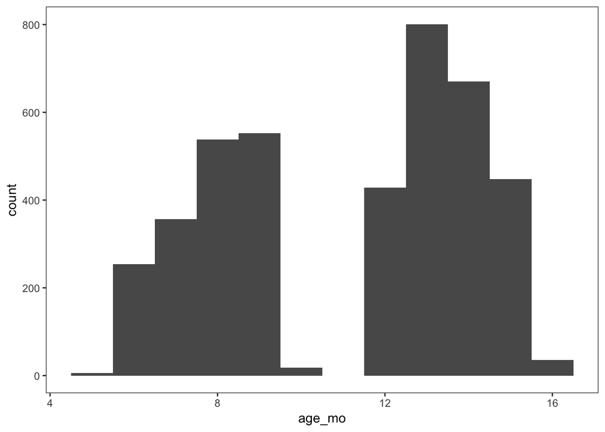

```r
month <- 365.25 / 12

d$age_mo <- d$age_days / month
ggplot(d, aes(x = age_mo)) +
  geom_histogram(binwidth = 1)
```

```r
d$age_group <- cut(d$age_mo, c(3,6,9,12,15),
                   labels = c("3-6 mo","6-9 mo","9-12 mo","12-15 mo"),
                   include.lowest = TRUE)
max(d$age_mo, na.rm=TRUE)
```

```
## [1] 16.22998
```

```r
d %>%
  filter(is.na(age_group)) %>%
  select(lab, subid, age_mo, age_group) %>%
  unique()
```

```
## # A tibble: 23 x 4
##    lab             subid              age_mo age_group
##    <chr>           <chr>               <dbl> <fct>
##  1 babylab-brookes babylab-brookesg6    15.2 <NA>
##  2 babylab-brookes babylab-brookesg9    15.3 <NA>
##  3 babylab-brookes babylab-brookesg10   15.4 <NA>
##  4 babylab-brookes babylab-brookesg11   15.1 <NA>
##  5 babylab-brookes babylab-brookesg17   15.1 <NA>
##  6 babylab-brookes babylab-brookesg75   15.2 <NA>
##  7 babylab-brookes babylab-brookesg91   15.1 <NA>
##  8 elp-georgetown  elp-georgetown8711   15.2 <NA>
##  9 elp-georgetown  elp-georgetown8869   15.3 <NA>
## 10 elp-georgetown  elp-georgetown8719   15.0 <NA>
## # … with 13 more rows
```

```r
# Some labs contributed data from babies outside the target age group

participants_by_lab_and_age_group = d %>%
  group_by(lab, age_group) %>%
  summarize(participants = n_distinct(subid))

print(participants_by_lab_and_age_group, n=1e4)
```

```
## # A tibble: 37 x 3
## # Groups:   lab [13]
##    lab                     age_group participants
##    <chr>                   <fct>            <int>
##  1 babylab-brookes         3-6 mo               7
##  2 babylab-brookes         6-9 mo              50
##  3 babylab-brookes         9-12 mo             16
##  4 babylab-brookes         12-15 mo            50
##  5 babylab-brookes         <NA>                 7
##  6 babylab-princeton       6-9 mo              19
##  7 babylab-princeton       12-15 mo            16
##  8 babylab-westernsydney   6-9 mo              31
##  9 babylab-westernsydney   9-12 mo              4
## 10 babylab-westernsydney   12-15 mo            30
## 11 babylab-westernsydney   <NA>                 2
```

[output cut: 26 more lines]

# 8 Dependent Variables

## 8.1 first_shift

Visualize some counts for first_shift

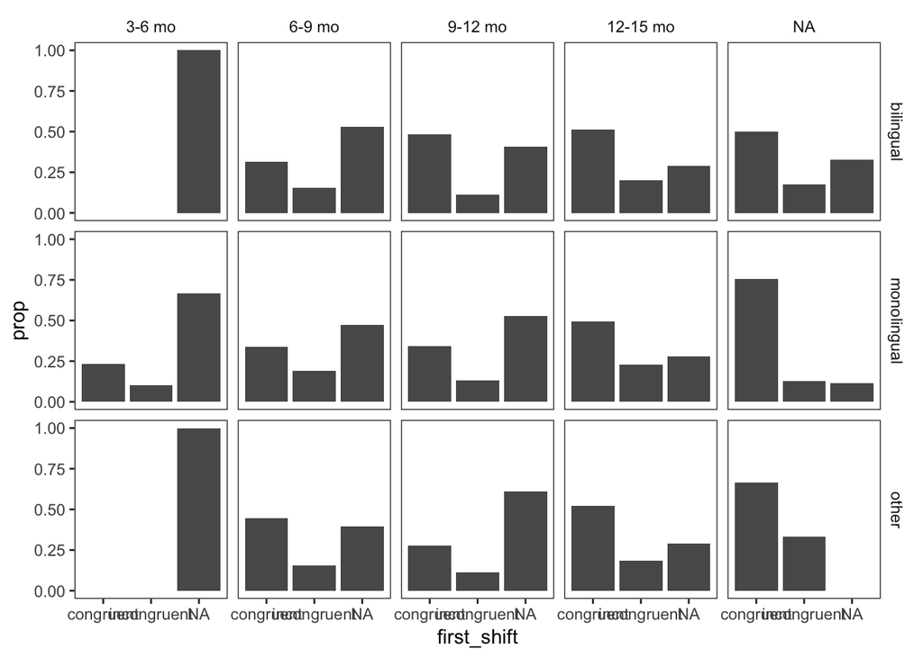

```r
d <- d %>%
  mutate(first_shift = as.factor(first_shift)) %>%
  replace_with_na(replace = list(first_shift = "na"))

d %>%
 # group_by(subid, first_shift, age_group, lang_group) %>%
  #summarize(n = n()) %>%
 # mutate(prop = n / sum(n)) %>%
  ggplot(aes(x = first_shift)) +
  geom_bar(aes(y = ..prop.., group = 1)) +
    facet_grid(lang_group ~ age_group)
```

# 9 latency

Get rid of a couple of out-of-range trials, and reset some latencies to start at 4000ms (when actor starts to turn head)

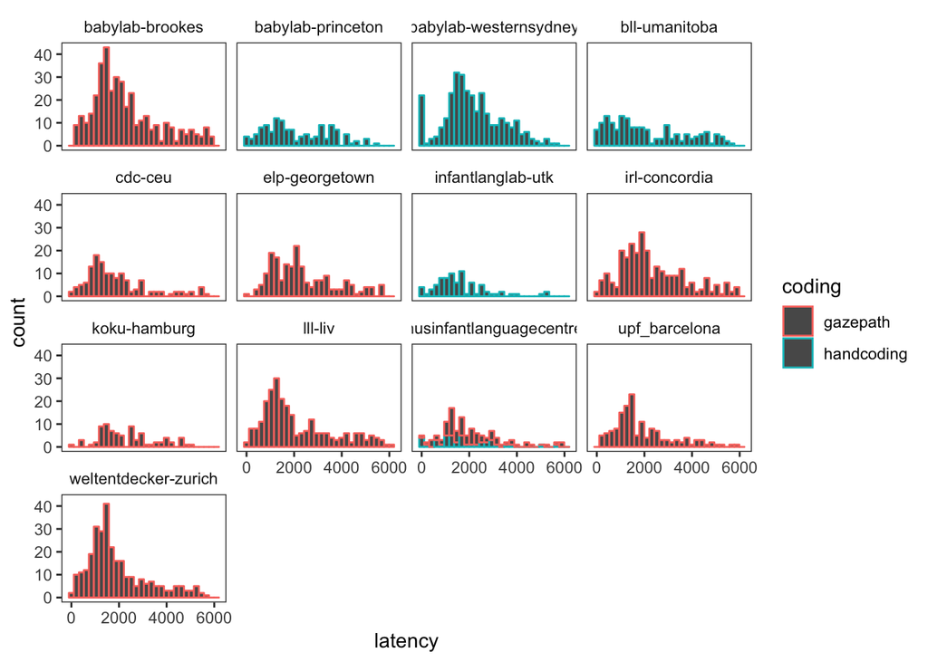

```r
# Convert from seconds to miliseconds
d$latency[d$lab == "babylab-westernsydney"] <- 1000*d$latency[d$lab == "babylab-westernsydney"]
# Correct the single error in westernsydney data
d$latency[d$subid == "2344"] <- d$latency[d$subid == "2344"]/1000

d <- d %>%
  group_by(lab, coding) %>%
  mutate(lab_min = min(latency, na.rm = TRUE)) %>%
  mutate(latency = case_when(
    lab_min >= 4000 ~ latency - 4000,
    lab_min <= 4000 ~ latency)) %>%
  filter(latency <= 10000 | is.na(latency))


latencies <- d %>%
  group_by(lab, coding) %>%
  summarise(min = min(latency, na.rm = TRUE), max = max(latency, na.rm = TRUE), mean = mean(latency, na.rm=TRUE), range = max-min)


write_csv(latencies, "metadata/to_check_latencies.csv")

d %>% ggplot(aes(x = latency, color = coding)) +
  geom_histogram() +
  facet_wrap(.~lab)
```

# 10 n_shift_congruent

```r
d <- d %>%
   mutate(n_shift_congruent = as.integer(n_shift_congruent))

d %>%
  group_by(lab) %>%
  summarise(min = min(n_shift_congruent, na.rm = TRUE), max = max(n_shift_congruent, na.rm = TRUE), mean = mean(n_shift_congruent, na.rm=TRUE))
```

```
## # A tibble: 13 x 4
##    lab                       min   max  mean
##    <chr>                   <dbl> <dbl> <dbl>
##  1 babylab-brookes             0     5 0.719
##  2 babylab-princeton           0     3 0.514
##  3 babylab-westernsydney       0     3 1
##  4 bll-umanitoba               0     4 0.775
##  5 cdc-ceu                     0     3 0.977
##  6 elp-georgetown              0     4 0.865
##  7 infantlanglab-utk           0     3 0.531
##  8 irl-concordia               0     4 0.798
##  9 koku-hamburg                0     4 0.873
## 10 lll-liv                     0     5 1
## 11 nusinfantlanguagecentre     0     3 0.595
## 12 upf_barcelona               0     3 0.865
## 13 weltentdecker-zurich        0     3 1.12
```

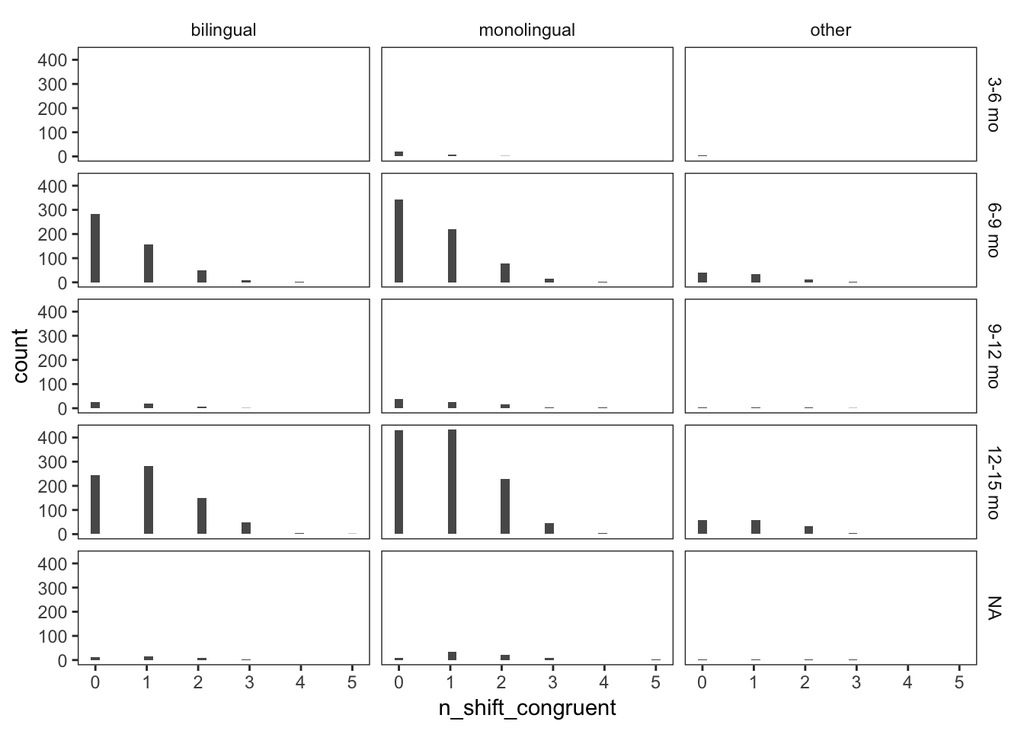

```r
d %>%
  ggplot(aes(x = n_shift_congruent)) +
  geom_histogram() +
  facet_grid(age_group ~ lang_group)
```

Everything looks as expected. Values between 0 and 5

# 11 n_shift_incongruent

```r
d <- d %>%
    mutate(n_shift_incongruent = as.integer(n_shift_incongruent))

d %>%
  group_by(lab) %>%
  summarise(min = min(n_shift_congruent, na.rm = TRUE), max = max(n_shift_congruent, na.rm = TRUE), mean = mean(n_shift_congruent, na.rm=TRUE))
```

```
## # A tibble: 13 x 4
##    lab                       min   max  mean
##    <chr>                   <dbl> <dbl> <dbl>
##  1 babylab-brookes             0     5 0.719
##  2 babylab-princeton           0     3 0.514
##  3 babylab-westernsydney       0     3 1
##  4 bll-umanitoba               0     4 0.775
##  5 cdc-ceu                     0     3 0.977
##  6 elp-georgetown              0     4 0.865
##  7 infantlanglab-utk           0     3 0.531
##  8 irl-concordia               0     4 0.798
##  9 koku-hamburg                0     4 0.873
## 10 lll-liv                     0     5 1
## 11 nusinfantlanguagecentre     0     3 0.595
## 12 upf_barcelona               0     3 0.865
## 13 weltentdecker-zurich        0     3 1.12
```

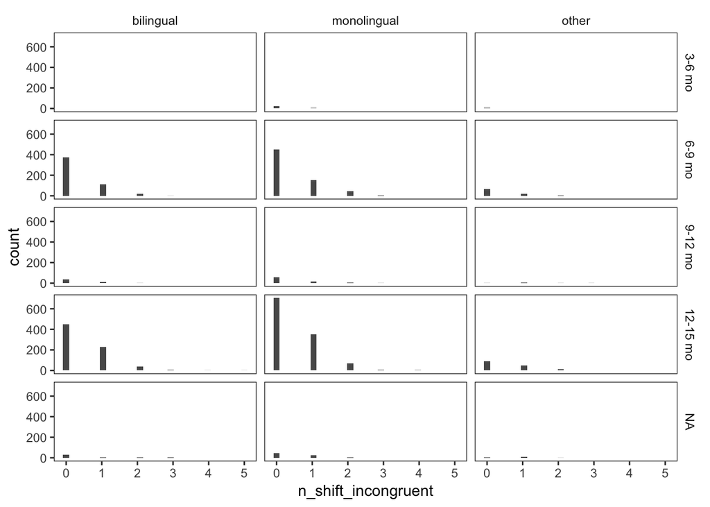

```r
d %>%
  ggplot(aes(x = n_shift_incongruent)) +
  geom_histogram() +
  facet_grid(age_group ~ lang_group)
```

Everything looks as expected. Values between 0 and 5

As per pre-reg, we will exclude babies who did not make a face-to-object saccade in at least 3 trials

```r
d <- d %>%
  mutate(has_shift = case_when(
    is.na(first_shift) ~ FALSE,
    first_shift == "congruent" ~ TRUE,
    first_shift == "incongruent" ~ TRUE)) %>%
  group_by(lab, subid) %>%
  summarize(n_has_shift = sum(has_shift)) %>%
  mutate(shifts_incl = case_when(
         n_has_shift >= 3 ~ TRUE,
         n_has_shift < 3 ~ FALSE)) %>%
  select(-n_has_shift) %>%
  right_join(d) %>%
  select(everything(), shifts_incl)

babies_shifts_ok <- length(unique(d$subid[d$shifts_incl == TRUE]))
babies_shifts_not_ok <- length(unique(d$subid[d$shifts_incl == FALSE]))
```

There are 494 infants who meet the criteria for shifts on at least 3 trials, and 200 who do not. This criterion excludes 28.8184438% of infants.

# 12 fixation_congruent

```r
d <- d %>%
  mutate(fixation_congruent = as.numeric(fixation_congruent))

d$fixation_congruent <- replace_na(d$fixation_congruent, 0) #Replace NAs with zeros

#convert babylab-westernsydney to milliseconds
d <- d %>% mutate(fixation_congruent = ifelse(lab == "babylab-westernsydney", fixation_congruent*1000, fixation_congruent))
#one trial was already in milliseconds
d$fixation_congruent = ifelse(d$fixation_congruent == 919000, 919, d$fixation_congruent)

d %>%
  group_by(lab) %>%
  summarise(min = min(fixation_congruent, na.rm = TRUE), max = max(fixation_congruent, na.rm = TRUE), mean = mean(fixation_congruent, na.rm=TRUE))
```

```
## # A tibble: 13 x 4
##    lab                       min   max  mean
##    <chr>                   <dbl> <dbl> <dbl>
##  1 babylab-brookes             0 4671   523.
##  2 babylab-princeton           0 4300   444.
##  3 babylab-westernsydney       0 9216  1253.
##  4 bll-umanitoba               0 4224   726.
##  5 cdc-ceu                     0 3049   698.
##  6 elp-georgetown              0 4916.  764.
##  7 infantlanglab-utk           0 2607   765.
##  8 irl-concordia               0 5330.  542.
##  9 koku-hamburg                0 3820   564.
## 10 lll-liv                     0 5395   727.
## 11 nusinfantlanguagecentre     0 5086   382.
## 12 upf_barcelona               0 4457.  613.
## 13 weltentdecker-zurich        0 3799   795.
```

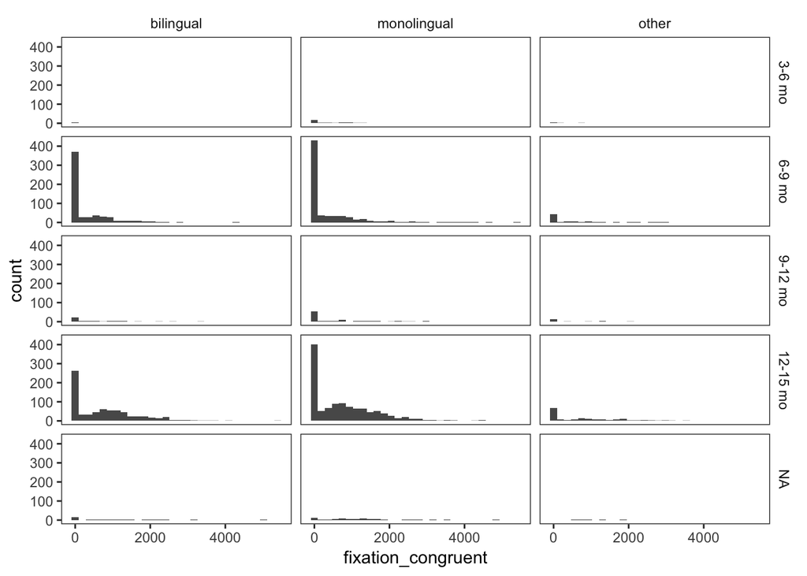

```r
d %>%
  filter(lab != "babylab-westernsydney") %>%
  ggplot(aes(x = fixation_congruent)) +
  geom_histogram() +
  facet_grid(age_group ~ lang_group)
```

```r
#replace NAs with zeros
```

```r
d <- d %>%
  mutate(fixation_incongruent = as.numeric(fixation_incongruent))

d$fixation_incongruent <- replace_na(d$fixation_incongruent, 0) #Replace NAs with zeros

#convert babylab-westernsydney to milliseconds
d <- d %>% mutate(fixation_incongruent = ifelse(lab == "babylab-westernsydney", fixation_incongruent*1000, fixation_incongruent))

d %>%
  group_by(lab) %>%
  summarise(min = min(fixation_incongruent, na.rm = TRUE), max = max(fixation_incongruent, na.rm = TRUE), mean = mean(fixation_incongruent, na.rm=TRUE))
```

```
## # A tibble: 13 x 4
##    lab                       min   max  mean
##    <chr>                   <dbl> <dbl> <dbl>
##  1 babylab-brookes             0 3597   297.
##  2 babylab-princeton           0 2867   346.
##  3 babylab-westernsydney       0 4421   557.
##  4 bll-umanitoba               0 3993   571.
##  5 cdc-ceu                     0 2413   479.
##  6 elp-georgetown              0 3839.  431.
##  7 infantlanglab-utk           0 4554  1181.
##  8 irl-concordia               0 4097   334.
##  9 koku-hamburg                0 2756.  206.
## 10 lll-liv                     0 3216   430.
## 11 nusinfantlanguagecentre     0 5943   273.
## 12 upf_barcelona               0 3264.  431.
## 13 weltentdecker-zurich        0 3495   499.
```

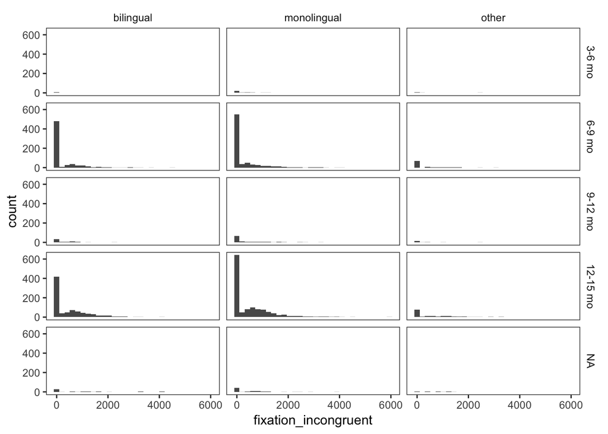

```r
d %>%
  ggplot(aes(x = fixation_incongruent)) +
  geom_histogram() +
  facet_grid(age_group ~ lang_group)
```

# 13 Output

Output intermediate file.

```r
write_csv(d, "processed_data/02_validated_output.csv")
```